# Startups_ProfitPredictor

## A Basic Machine Learning Model using Multivariate Linear and Multivariate Polynomial Regression

Here we will be looking at the various basic data cleaning techniques, visualization techiniques and then finally build a model, to predict the profits of new startup companies, using Multivariate Linear Regression(a type of linear regression in which more than one independent variable (predictors) and more than one dependent variable (responses), are linearly related)and Multivariate Polynomial Regression(a type of polynomial regression in which more than one independent variable (predictors) and more than one dependent variable (responses), are polynomially(eg: quadratic,cubic,etc.,.) related).

We will then go ahead to compare between Linear and Polynomial regression, to see which model gives a better result for our dataset.

```python
#importing the required packages

import numpy as np
import pandas as pd
from matplotlib import pyplot as plt
from sklearn.model_selection import train_test_split
from sklearn.linear_model import LinearRegression
from sklearn.preprocessing import PolynomialFeatures
from sklearn import metrics
import seaborn as sns
```

```python
#loading the dataset and checking it

df = pd.read_csv('50_startups.csv')
df.head()
```

|  | R&D Spend | Administration | Marketing Spend | State | Profit |
| --- | --- | --- | --- | --- | --- |
| 0 | 165349.20 | 136897.80 | 471784.10 | New York | 192261.83 |
| 1 | 162597.70 | 151377.59 | 443898.53 | California | 191792.06 |
| 2 | 153441.51 | 101145.55 | 407934.54 | Florida | 191050.39 |
| 3 | 144372.41 | 118671.85 | 383199.62 | New York | 182901.99 |
| 4 | 140143.50 | NaN | NaN | Florida | 134307.35 |

```python
#looking at some of the statical values to better understand the data

df.describe()
```

|  | R&D Spend | Administration | Marketing Spend | Profit |
| --- | --- | --- | --- | --- |
| count | 53.000000 | 51.000000 | 52.000000 | 52.000000 |
| mean | 75374.625283 | 120805.798627 | 206471.538269 | 113097.331923 |
| std | 46133.031203 | 28001.877707 | 123424.029117 | 39902.857207 |
| min | 0.000000 | 51283.140000 | 0.000000 | 14681.400000 |
| 25% | 44069.950000 | 102101.520000 | 125324.665000 | 90518.427500 |
| 50% | 73994.560000 | 122616.840000 | 208157.655000 | 108643.015000 |
| 75% | 114523.610000 | 144606.780000 | 298932.675000 | 142253.990000 |
| max | 165349.200000 | 182645.560000 | 471784.100000 | 192261.830000 |

```python
#Data Preprocessing

#Removing all the rows with nan values, if not they will affect our model's accuracy

print(df.isnull().sum())
df = df.dropna()          #inbuilt function of pandas.Dataframe to remove all the nan values
df.describe()
```

```
R&D Spend          0
Administration     2
Marketing Spend    1
State              1
Profit             1
dtype: int64
```

|  | R&D Spend | Administration | Marketing Spend | Profit |
| --- | --- | --- | --- | --- |
| count | 50.000000 | 50.000000 | 50.000000 | 50.000000 |
| mean | 73721.615600 | 121344.639600 | 211025.097800 | 112012.639200 |
| std | 45902.256482 | 28017.802755 | 122290.310726 | 40306.180338 |
| min | 0.000000 | 51283.140000 | 0.000000 | 14681.400000 |
| 25% | 39936.370000 | 103730.875000 | 129300.132500 | 90138.902500 |
| 50% | 73051.080000 | 122699.795000 | 212716.240000 | 107978.190000 |
| 75% | 101602.800000 | 144842.180000 | 299469.085000 | 139765.977500 |
| max | 165349.200000 | 182645.560000 | 471784.100000 | 192261.830000 |

```python
#Changing all the zeros to nan so that we can fill them with relevant values

df = df.replace(0.0, np.nan)
df.isnull().sum()
```

```
R&D Spend          2
Administration     0
Marketing Spend    3
State              0
Profit             0
dtype: int64
```

```python
#Replacing all the zeros that were converted into nan before by the mean of those columns

df['R&D Spend'].fillna(df['R&D Spend'].mean(), inplace = True)
df['Marketing Spend'].fillna(df['Marketing Spend'].mean(), inplace = True)
df.isnull().sum()
```

```
R&D Spend          0
Administration     0
Marketing Spend    0
State              0
Profit             0
dtype: int64
```

```python
#Checking the correlation matrix of the data

df.corr()
```

|  | R&D Spend | Administration | Marketing Spend | Profit |
| --- | --- | --- | --- | --- |
| R&D Spend | 1.000000 | 0.268979 | 0.666533 | 0.881354 |
| Administration | 0.268979 | 1.000000 | -0.070590 | 0.200717 |
| Marketing Spend | 0.666533 | -0.070590 | 1.000000 | 0.693088 |
| Profit | 0.881354 | 0.200717 | 0.693088 | 1.000000 |

```python
#Checking the number of startups in each State

Startups_in_New_York = df.loc[df['State']=='New York']
Startups_in_California = df.loc[df['State']=='California']
Startups_in_Florida = df.loc[df['State']=='Florida']
print("Number of startups in New York", len(Startups_in_New_York))
print("Number of startups in California", len(Startups_in_California))
print("Number of startups in Florida", len(Startups_in_Florida))
```

```
Number of startups in New York 17
Number of startups in California 17
Number of startups in Florida 16
```

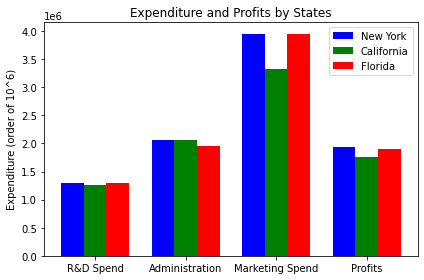

```python
#Data Visualization

#Here we draw the plot bar graph of the spendings by the startups organised by States

fig = plt.figure()
fig, ax = plt.subplots()
cities = [i for i in df['State'].unique()]

#Get the total of the profits and spendings of the startups in each State

Profits = [round(Startups_in_New_York['Profit'].sum()), round(Startups_in_California['Profit'].sum()), \
           round(Startups_in_Florida['Profit'].sum())]
RD_Spend = [round(Startups_in_New_York['R&D Spend'].sum()), round(Startups_in_California['R&D Spend'].sum()), \
            round(Startups_in_Florida['R&D Spend'].sum())]
Administration = [round(Startups_in_New_York['Administration'].sum()), round(Startups_in_California['Administration'].sum()), \
                  round(Startups_in_Florida['Administration'].sum())]
Marketing = [round(Startups_in_New_York['Marketing Spend'].sum()), round(Startups_in_California['Marketing Spend'].sum()), \
             round(Startups_in_Florida['Marketing Spend'].sum())]

New_york = [RD_Spend[0], Administration[0], Marketing[0], Profits[0]]
California = [RD_Spend[1], Administration[1], Marketing[1], Profits[1]]
Florida = [RD_Spend[2], Administration[2], Marketing[2], Profits[2]]

#Draw the bar graph and set proper labels, legend, etc.,.

labels = ['R&D Spend', 'Administration', 'Marketing Spend', 'Profits']
X = np.arange(len(labels))
ax.set_title('Expenditure and Profits by States')
ax.bar(X - 0.25, New_york, color = 'b', width = 0.25, label='New York')
ax.bar(X + 0.00, California, color = 'g', width = 0.25, label='California')
ax.bar(X + 0.25, Florida, color = 'r', width = 0.25, label='Florida')

ax.set_ylabel('Expenditure (order of 10^6)')
ax.set_xticks(X)
ax.set_xticklabels(labels)
ax.legend()

fig.tight_layout()

plt.show()
```

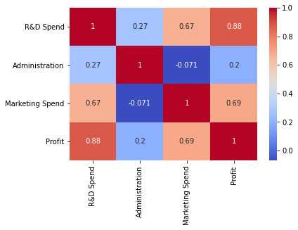

```python
#Draw the heat map of the data for analysis

plt.figure()
sns.heatmap(df.corr(), cmap='coolwarm', annot=True)
plt.show()
```

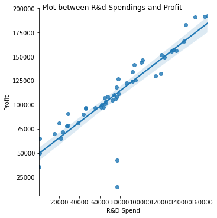

```python
#Draw the graphs between each independant variable and dependant variable for analysis

sns.lmplot(x='R&D Spend', y='Profit', data=df).fig.suptitle("Plot between R&d Spendings and Profit", fontsize=12)
```

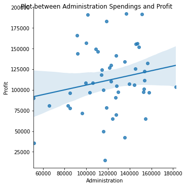

```python
fig = sns.lmplot(x='Administration', y='Profit', data=df)
fig = fig.fig
fig.suptitle("Plot between Administration Spendings and Profit", fontsize=12)
```

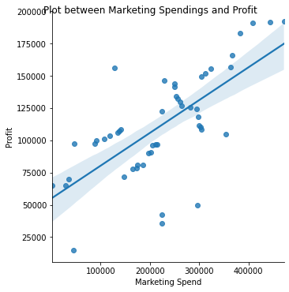

```python
sns.lmplot(x='Marketing Spend', y='Profit', data=df).fig.suptitle("Plot between Marketing Spendings and Profit", fontsize=12)
```

```python
#Data Preprocessing

#Perform one-hot encoding to reduce the ordinal data of State to a form that can be used to build the model

one_hot = pd.get_dummies(df['State'])
df = df.drop('State', axis=1)
df = df.join(one_hot)
prof = df['Profit']
df = df.drop('Profit', axis=1).join(prof)
df.head()
```

|  | R&D Spend | Administration | Marketing Spend | California | Florida | New York | Profit |
| --- | --- | --- | --- | --- | --- | --- | --- |
| 0 | 165349.20 | 136897.80 | 471784.10 | 0 | 0 | 1 | 192261.83 |
| 1 | 162597.70 | 151377.59 | 443898.53 | 1 | 0 | 0 | 191792.06 |
| 2 | 153441.51 | 101145.55 | 407934.54 | 0 | 1 | 0 | 191050.39 |
| 3 | 144372.41 | 118671.85 | 383199.62 | 0 | 0 | 1 | 182901.99 |
| 5 | 142107.34 | 91391.77 | 366168.42 | 0 | 1 | 0 | 166187.94 |

```python
#Check the correlation values

df.corr()
```

|  | R&D Spend | Administration | Marketing Spend | California | Florida | New York | Profit |
| --- | --- | --- | --- | --- | --- | --- | --- |
| R&D Spend | 1.000000 | 0.268979 | 0.666533 | -0.051912 | 0.062887 | -0.010015 | 0.881354 |
| Administration | 0.268979 | 1.000000 | -0.070590 | -0.015478 | 0.010493 | 0.005145 | 0.200717 |
| Marketing Spend | 0.666533 | -0.070590 | 1.000000 | -0.189842 | 0.144084 | 0.047958 | 0.693088 |
| California | -0.051912 | -0.015478 | -0.189842 | 1.000000 | -0.492366 | -0.515152 | -0.145837 |
| Florida | 0.062887 | 0.010493 | 0.144084 | -0.492366 | 1.000000 | -0.492366 | 0.116244 |
| New York | -0.010015 | 0.005145 | 0.047958 | -0.515152 | -0.492366 | 1.000000 | 0.031368 |
| Profit | 0.881354 | 0.200717 | 0.693088 | -0.145837 | 0.116244 | 0.031368 | 1.000000 |

```python
#Remove the column of New-York to prevent 'Dummy Variable Trap', which is caused due to the redundant data that
#was obtained due to the one hot encoding performed on States column

df = df.drop('New York', axis=1)
df.head()
```

|  | R&D Spend | Administration | Marketing Spend | California | Florida | Profit |
| --- | --- | --- | --- | --- | --- | --- |
| 0 | 165349.20 | 136897.80 | 471784.10 | 0 | 0 | 192261.83 |
| 1 | 162597.70 | 151377.59 | 443898.53 | 1 | 0 | 191792.06 |
| 2 | 153441.51 | 101145.55 | 407934.54 | 0 | 1 | 191050.39 |
| 3 | 144372.41 | 118671.85 | 383199.62 | 0 | 0 | 182901.99 |
| 5 | 142107.34 | 91391.77 | 366168.42 | 0 | 1 | 166187.94 |

```python
#Building the model

#Split the data into train and test data(80% and 20%)

X = df.iloc[:,:-1].values
y = df.iloc[:,5].values
X_train, X_test, y_train, y_test = train_test_split(X, y, test_size = 0.2, random_state = 0)
```

Multivariate regression is a technique that estimates a single regression model with more than one outcome variable. When there is more than one predictor variable in a multivariate regression model, the model is a multivariate multiple regression.

### Predicting the Profit using Multivariate Linear Regression

Multivariate Linear Regression is quite similar to the simple linear regression model, but with multiple independent variables contributing to the dependent variable and hence multiple coefficients to determine and complex computation due to the added variables.

Multivariate Linear Regression in a quadratic equation is of the form

y = m1.a1 + m2.a2 + m3.a3 + ..... + mn.an + a0 where '.' represents multiplication

```python
#Train the model with the train dataset

regressor = LinearRegression()
regressor.fit(X_train, y_train)
print(regressor.intercept_)
print(regressor.coef_)
```

```
33616.46584790526
[ 6.45209703e-01  1.00425490e-01  8.15150660e-02 -6.68132451e+03
 -1.81773441e+03]
```

```python
#Run the model trained on the test values to obtain the predicted values

predictions = regressor.predict(X_test)
```

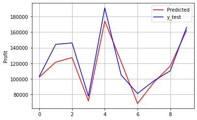

```python
#Plot the values obtained by predicting using the model trained and the actual test values to evaluate our model's performance

plt.grid(True)
plt.plot(predictions, color = 'red', label = 'Predicted')
plt.plot(y_test, color = 'blue', label = 'y_test')
plt.legend()
plt.ylabel('Profit')
plt.show()
```

#### Some conclusions are

1. The predicted values are close to the actual values which signifies that our model is a reasonable one and can be employed for real world problems.
2. Huge variation can be seen for a few values in the start but then that can be attributed to the small size of our dataset, the prediction can be made even more accurate if we have more data to train our model.

```python
#Display the accuracy metrics to check the model's accuracy

print(f'The mean squared error is {metrics.mean_squared_error(y_test, predictions):0.3f}')
print(f'The mean squared log error is {metrics.mean_squared_log_error(y_test, predictions):0.3f}')
print(f'The r2 score {metrics.r2_score(y_test, predictions):0.3f}')
print(f'The MAPE(mean absolute percentage error) is {metrics.mean_absolute_percentage_error(y_test, predictions):0.4f}')
```

```
The mean squared error is 169556941.602
The mean squared log error is 0.012
The r2 score 0.867
The MAPE(mean absolute percentage error) is 0.0877
```

Mean squared error regression loss is a a non-negative floating point value(0.0 being the value of an ideal model), which is a measure the average of the squares of the errors—that is, the average squared difference between the estimated values and the actual value.

Mean squared logarithmic error regression loss is a non-negative floating point value(0.0 being the value of an ideal model), which is a measure of the relative difference between the real and predicted values.

R2(coefficient of determination) regression score function is a floating-point value which can also be negative(1.0 being the value of an ideal model), which is a statistical measure of how close the data are to the fitted regression line. It is also known as the coefficient of determination, or the coefficient of multiple determination for multiple regression.

Mean absolute percentage error regression loss (MAPE), is non-negative floating point(0.0 being the value of an ideal model), which is a measure of how accurate a forecast system is. It measures this accuracy as a percentage, and can be calculated as the average absolute percent error for each period minus actual values divided by actual values.

### Predicting the Profit using Multivariate polynomial Regression

In Polynomial Regression, the relationship between the response and the Regressor variable is modelled as the nth order polynomial equation. It is used when the response variable is non-linear, i.e., the scatter plot gives a non-linear or curvilinear structure.

Multivariate Polynomial Regression in a quadratic equation is of the form

y = B0 + B1.x1 + B2.x2 + B3.x3 + ..... + Bn.xn + c where xi = x^i and '.' represents multiplication

#### We first build a model with polynomial of degree 2 (a quadratic polynomial)

```python
#Train the model of polynomial degree 2(quadratic) with the train dataset

poly_reg = PolynomialFeatures(degree = 2)
X_poly = poly_reg.fit_transform(X_train)
regressor.fit(X_poly, y_train)
poly_predictions = regressor.predict(poly_reg.fit_transform(X_test))
print(regressor.intercept_)
print(regressor.coef_)
```

```
-21923.12457033462
[ 0.00000000e+00 -1.41665854e-01  6.16920263e-01  5.00369098e-01
  3.17002951e+03  4.23139378e+04  2.82288975e-06  5.01502837e-07
  2.34773874e-06 -1.83763796e-01 -5.76324989e-02  5.10760117e-07
 -2.53270963e-06 -1.72526114e-01 -5.94836366e-01 -9.12984565e-07
  1.21902855e-01 -4.92134360e-03  3.16993683e+03  0.00000000e+00
  4.23139445e+04]
```

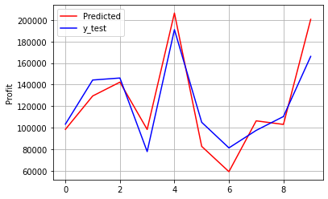

```python
#Plot the values obtained by predicting using the model trained and the actual test values to evaluate our model's performance

plt.grid(True)
plt.plot(poly_predictions, color = 'red', label = 'Predicted')
plt.plot(y_test, color = 'blue', label = 'y_test')
plt.legend()
plt.ylabel('Profit')
plt.show()
```

```python
#Display the accuracy metrics to check the model's accuracy

print(f'The mean squared error is {metrics.mean_squared_error(y_test, poly_predictions):0.3f}')
print(f'The mean squared log error is {metrics.mean_squared_log_error(y_test, poly_predictions):0.3f}')
print(f'The r2 score {metrics.r2_score(y_test, poly_predictions):0.3f}')
print(f'The MAPE(mean absolute percentage error) is {metrics.mean_absolute_percentage_error(y_test, poly_predictions):0.4f}')
```

```
The mean squared error is 322091193.499
The mean squared log error is 0.028
The r2 score 0.748
The MAPE(mean absolute percentage error) is 0.1370
```

#### We then build a model with polynomial of degree 3 (a cubic polynomial)

```python
#Train the model of polynomial degree 3(cubic) with the train dataset

poly_reg = PolynomialFeatures(degree = 3)
X_poly = poly_reg.fit_transform(X_train)
regressor.fit(X_poly, y_train)
poly_predictions = regressor.predict(poly_reg.fit_transform(X_test))
print(regressor.intercept_)
print(regressor.coef_)
```

```
-584468.1581369315
[ 1.78822827e-01  1.33405614e+00  2.48488933e+01 -8.74834451e+00
  5.62136114e-02 -2.25643326e-02 -2.40168715e-04  2.60377673e-04
  4.30010580e-06 -9.34972752e+00 -1.24234254e+01 -2.86754414e-04
  5.43245439e-05 -2.49193281e+00  8.15868768e+00  3.05081937e-05
  4.18832001e+00 -1.73543604e+00 -1.16825945e-03  6.57621572e-09
  2.88139840e-04 -2.52021870e-09  4.58124938e-09  1.23894894e-09
 -1.66080092e-05 -2.81182435e-04 -2.60037414e-09 -1.36251899e-09
  1.51650569e-04  2.92670027e-04 -8.85345131e-11  2.63452897e-05
  1.18912698e-04 -9.37599742e+00 -3.55271368e-15 -1.24224394e+01
  1.04181552e-09  2.72109446e-10  2.88646858e-05 -1.22939299e-04
 -8.26894109e-11 -6.43771680e-05 -5.89964253e-06 -2.48398950e+00
  0.00000000e+00  8.17592997e+00 -1.64988023e-11 -6.76084753e-06
 -8.83204607e-06  4.18832006e+00  0.00000000e+00 -1.73543604e+00
 -1.16825747e-03  0.00000000e+00  0.00000000e+00  2.88143497e-04]
```

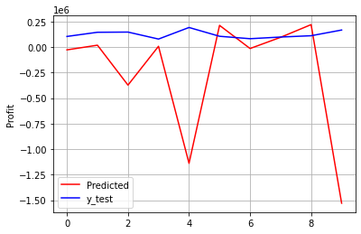

```python
#Plot the values obtained by predicting using the model trained and the actual test values to evaluate our model's performance

plt.grid(True)
plt.plot(poly_predictions, color = 'red', label = 'Predicted')
plt.plot(y_test, color = 'blue', label = 'y_test')
plt.legend()
plt.ylabel('Profit')
plt.show()
```

```python
#Display the accuracy metrics to check the model's accuracy

print(f'The mean squared error is {metrics.mean_squared_error(y_test, poly_predictions):0.3f}')
print(f'The r2 score {metrics.r2_score(y_test, poly_predictions):0.3f}')
print(f'The MAPE(mean absolute percentage error) is {metrics.mean_absolute_percentage_error(y_test, poly_predictions):0.4f}')
```

```
The mean squared error is 498741204438.709
The r2 score -388.979
The MAPE(mean absolute percentage error) is 2.7004
```

The degree 1 was left out on purpose since we had built a model with it, degree 1 means that the model is a linear model which in our case translates to multivariate linear regression(one that we did before this).

A polynomial of degree 1 is called as a linear polynomial or a line and this can be proved by taking the degree 1 inside the Polynomial features and cross comparing the output produced by the model, only to see it similar to the one we obtained initially from performing multivariate linear regression.

#### Model with polynomial of degree 1 (a linear polynomial / straight line)

```python
#Train the model of polynomial degree 1(linear) with the train dataset

poly_reg = PolynomialFeatures(degree = 1)
X_poly = poly_reg.fit_transform(X_train)
regressor.fit(X_poly, y_train)
poly_predictions = regressor.predict(poly_reg.fit_transform(X_test))
print(regressor.intercept_)
print(regressor.coef_)
```

```
33616.46585010277
[ 0.00000000e+00  6.45209703e-01  1.00425490e-01  8.15150660e-02
 -6.68132451e+03 -1.81773441e+03]
```

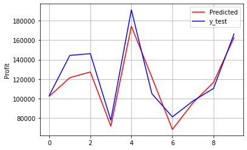

```python
#Plot the values obtained by predicting using the model trained and the actual test values to evaluate our model's performance

plt.grid(True)
plt.plot(poly_predictions, color = 'red', label = 'Predicted')
plt.plot(y_test, color = 'blue', label = 'y_test')
plt.legend()
plt.ylabel('Profit')
plt.show()
```

```python
#Display the accuracy metrics to check the model's accuracy

print(f'The mean squared error is {metrics.mean_squared_error(y_test, poly_predictions):0.3f}')
print(f'The mean squared log error is {metrics.mean_squared_log_error(y_test, poly_predictions):0.3f}')
print(f'The r2 score {metrics.r2_score(y_test, poly_predictions):0.3f}')
print(f'The MAPE(mean absolute percentage error) is {metrics.mean_absolute_percentage_error(y_test, poly_predictions):0.4f}')
```

```
The mean squared error is 169556941.589
The mean squared log error is 0.012
The r2 score 0.867
The MAPE(mean absolute percentage error) is 0.0877
```

#### Some conclusions we can make are

1. From the accuracy measure statistics we can see that as the degree of polynomial, being used to build the model, increases our model's accuracy tends to decrease. This can be seen from the r2 score of polynomial degree 1 (linear polynomial model) which is 0.867, r2 score of polynomial degree 2 (quadratic polynomial model) which is 0.748 and r2 score of polynomial degree 3 (cubic polynomial model) which is -388.979(hell of an error i.e the model is completely wrong). Based on the r2 and other metrics scores we can confidently say that as the degree increases model becomes worse off (this can be seen from degree 3 onwards).
2. Since polynomial of degree 1 is a linear one, which is same as the one we obtained using multivariate linear regression, we can say that for out dataset multivariate linear regression is the best model. This is because we are only dealing with 4 variables (3 independant and 1 dependant) which correlate with each other directly and in a simple way (i.e if any one increases the dependant variable also increases), and it is scenarios like this that are what are best predicted using multivariate linear regression.
3. Polynomial regression works best when there are many variables and the relationship between them are kind of complex, more the complexity of the relationship amongst variables the better a model built using a higher degree polynomial would perform.

#### Thus we have compared between Multivariate Linear regression and Multivariate Polynomial regression, thereby proving that for our dataset (a simple dataset on profits made by startups) the best model would be that obtained through Multivariate Linear regression.